# hw_3

Ekaterina Uetova

```r
library(tidyverse)
library(bootstrap)
library(mosaic)
```

### 1.1

Посчитайте среднее употребление слова “сэр” по каждой главе, а потом посчитайте grand mean. Ответ выведите в формате тиббл.

```r
df <- read_csv("https://raw.githubusercontent.com/euetova/2018_data_analysis_for_linguists/master/hw3_binomial_ci/hw3_wodehouse.csv")
df <- as_tibble(df)
```

```r
df %>%
  filter(word == "сэр") %>%
  select(chapter) %>%
  count(chapter) -> chapter_sir
df %>%
  group_by(chapter) %>%
  count(chapter) -> all_words
chapter_sir['all_words'] <- all_words$n
chapter_sir %>%
  mutate(average = n/all_words) %>%
  arrange(desc(average)) -> chapter_sir
as_tibble(chapter_sir)
```

| chapter | n | all_words | average |
| --- | --- | --- | --- |
| Глава 14 | 77 | 5308 | 0.0145064054 |
| Глава 11 | 49 | 4008 | 0.0122255489 |
| Глава 12 | 19 | 2239 | 0.0084859312 |
| Глава 2 | 35 | 4214 | 0.0083056478 |
| Глава 13 | 22 | 2745 | 0.0080145719 |
| Глава 8 | 42 | 6547 | 0.0064151520 |
| Глава 10 | 12 | 3230 | 0.0037151703 |
| Глава 1 | 17 | 4804 | 0.0035387177 |
| Глава 9 | 10 | 3947 | 0.0025335698 |
| Глава 3 | 8 | 6833 | 0.0011707888 |

[output cut: 1 more lines]

```r
as_tibble(mean(chapter_sir$average))
```

| value |
| --- |
| 0.006307625 |

### 1.2

Посчитайте бутстрэпом доверительный интервал для средней доли слова “сэр” в главах романа и выведите его размер в формате тиббл.

```r
set.seed(42)
sir_bs <- bootstrap(chapter_sir$average, nboot = 10000, theta = mean)$thetastar
sir_bs <- data_frame(means = sir_bs)
sir_bs %>%
  summarise(mean = mean(means),
            q1 = quantile(means, 0.025),
            q2 = quantile(means, 0.975))->
  sir_stats
as_tibble(sir_stats)
```

| mean | q1 | q2 |
| --- | --- | --- |
| 0.006305577 | 0.00383348 | 0.008888922 |

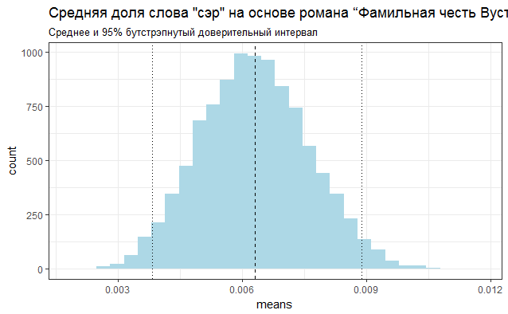

```r
sir_bs %>%
  ggplot(aes(means)) +
  geom_histogram(fill = "lightblue")+
  theme_bw()+
  labs(title = 'Средняя доля слова "сэр" на основе романа “Фамильная честь Вустеров”', subtitle = "Среднее и 95% бутстрэпнутый доверительный интервал")+
  geom_vline(xintercept = unlist(sir_stats), lty = c(2, 3, 3))
```

### 1.3

Посчитайте биномиальный доверительный интервал употребления слова “сэр” в каждой главе и выведите главу с максимальным из интервалов в формате тиббл.

```r
chapter_sir %>%
  group_by(chapter) %>%
  mutate(low_ci = binom.test(x = n, n = all_words, ci.method = "Clopper-Pearson")$conf.int[1],
         up_ci = binom.test(x = n, n = all_words, ci.method = "Clopper-Pearson")$conf.int[2]) %>%
  mutate(len = up_ci - low_ci)-> sir_bin
as_tibble(sir_bin) %>%
  filter (len == max(sir_bin$len))%>%
  select(chapter, len)
```

| chapter | len |
| --- | --- |
| Глава 12 | 0.008103647 |

### 1.4

Посчитайте байесовский биномиальный доверительный интервал употребления слова “сэр” в каждой главе и выведите главу с максимальным из интервалов в формате тиббл.

```r
mu <- mean(chapter_sir$average)
var <- var(chapter_sir$average)
alpha0 <- ((1 - mu) / var - 1 / mu) * mu ^ 2
beta0 <- alpha0 * (1 / mu - 1)
x <- seq(0, 0.1, length = 1000)
estimation <- data_frame(
  x = x,
  density = c(dbeta(x, shape1 = alpha0, shape2 = beta0)))
chapter_sir %>%
  mutate(alpha_post = n+alpha0,
         beta_post = all_words-n+beta0,
         average_post = alpha_post/(alpha_post+beta_post),
         cred_int_l = qbeta(.025, alpha_post, beta_post),
         cred_int_h = qbeta(.975, alpha_post, beta_post),
         length = cred_int_h - cred_int_l) -> posterior
as_tibble(posterior) %>%
  filter (length == max(posterior$length))%>%
  select(chapter, length)
```

| chapter | length |
| --- | --- |
| Глава 12 | 0.006984133 |

### 1.5

Посчитайте биномиальный доверительный интервал употребления слова “сэр” в каждой главе и выведите главу с минимальным из интервалов в формате тиббл.

```r
as_tibble(sir_bin) %>%
  filter (len == min(sir_bin$len))%>%
  select(chapter, len)
```

| chapter | len |
| --- | --- |
| Глава 3 | 0.001800016 |

### 1.6

Посчитайте байесовский биномиальный доверительный интервал употребления слова “сэр” в каждой главе и выведите главу с минимальным из интервалов в формате тиббл.

```r
as_tibble(posterior) %>%
  filter (length == min(posterior$length))%>%
  select(chapter, length)
```

| chapter | length |
| --- | --- |
| Глава 3 | 0.001714586 |

### 1.7

Напишите короткий текст, комментирующий наблюдаемые сходства/различия между оценками среднего и доверительных интервалов количества употреблений слова “сэр” во всех главах романа. Что можно сказать про разные главы? Что можно сказать о сходстве/различиях фриквентистсткой и байесовской оценок наблюдаемых параметров?

> Разница обычного среднего и стреднего по бутстрапу отличается всего лишь в тысячные доли, что говорит о сбалансированнности выборки. Размеры глав и встречаемость слова “сэр” сильно отличается. Фриквентистсткие и байесовские оценки параметров похожи.